# Lab 9

Zachary Palmore

2020-11-20

```r
library(tidyverse)
library(openintro)
```

### Pre-exercise

Adding the GGally package.

```r
# install.packages("GGally")
library(GGally)
```

Looking at the data from the course package.

```r
data(evals)
glimpse(evals)
```

```
## Rows: 463
## Columns: 23
## $ course_id     <int> 1, 2, 3, 4, 5, 6, 7, 8, 9, 10, 11, 12, 13, 14, 15, 16...
## $ prof_id       <int> 1, 1, 1, 1, 2, 2, 2, 3, 3, 4, 4, 4, 4, 4, 4, 4, 4, 5,...
## $ score         <dbl> 4.7, 4.1, 3.9, 4.8, 4.6, 4.3, 2.8, 4.1, 3.4, 4.5, 3.8...
## $ rank          <fct> tenure track, tenure track, tenure track, tenure trac...
## $ ethnicity     <fct> minority, minority, minority, minority, not minority,...
## $ gender        <fct> female, female, female, female, male, male, male, mal...
## $ language      <fct> english, english, english, english, english, english,...
## $ age           <int> 36, 36, 36, 36, 59, 59, 59, 51, 51, 40, 40, 40, 40, 4...
## $ cls_perc_eval <dbl> 55.81395, 68.80000, 60.80000, 62.60163, 85.00000, 87....
## $ cls_did_eval  <int> 24, 86, 76, 77, 17, 35, 39, 55, 111, 40, 24, 24, 17, ...
## $ cls_students  <int> 43, 125, 125, 123, 20, 40, 44, 55, 195, 46, 27, 25, 2...
## $ cls_level     <fct> upper, upper, upper, upper, upper, upper, upper, uppe...
## $ cls_profs     <fct> single, single, single, single, multiple, multiple, m...
## $ cls_credits   <fct> multi credit, multi credit, multi credit, multi credi...
## $ bty_f1lower   <int> 5, 5, 5, 5, 4, 4, 4, 5, 5, 2, 2, 2, 2, 2, 2, 2, 2, 7,...
## $ bty_f1upper   <int> 7, 7, 7, 7, 4, 4, 4, 2, 2, 5, 5, 5, 5, 5, 5, 5, 5, 9,...
## $ bty_f2upper   <int> 6, 6, 6, 6, 2, 2, 2, 5, 5, 4, 4, 4, 4, 4, 4, 4, 4, 9,...
## $ bty_m1lower   <int> 2, 2, 2, 2, 2, 2, 2, 2, 2, 3, 3, 3, 3, 3, 3, 3, 3, 7,...
## $ bty_m1upper   <int> 4, 4, 4, 4, 3, 3, 3, 3, 3, 3, 3, 3, 3, 3, 3, 3, 3, 6,...
## $ bty_m2upper   <int> 6, 6, 6, 6, 3, 3, 3, 3, 3, 2, 2, 2, 2, 2, 2, 2, 2, 6,...
## $ bty_avg       <dbl> 5.000, 5.000, 5.000, 5.000, 3.000, 3.000, 3.000, 3.33...
## $ pic_outfit    <fct> not formal, not formal, not formal, not formal, not f...
## $ pic_color     <fct> color, color, color, color, color, color, color, colo...
```

There are 463 rows and 23 columns.

Evaluating the type of study.

```r
?evals
```

```
## starting httpd help server ... done
```

### Exercise 1

Is this an observational study or an experiment? The original research question posed in the paper is whether beauty leads directly to the differences in course evaluations. Given the study design, is it possible to answer this question as it is phrased? If not, rephrase the question.

This is an observational study because the data gathered is not directly interfering with how the data arises and they are merely observing a natural phenomena.

With an observational study, we cannot make causal claims. We can only provide evidence that an association exists between two variables.

The question could be rephrased to ask, “is there an association between a professor’s attractiveness and their course evaluations?” which could be further broken down into a hypothesis test where:

$H_o$ There is no relationship between a professor’s attractiveness and their course evaluations.

$H_a$ There is a relationship between a professor’s attractiveness and their course evaluations.

It could then be tested to determine the validity of the association between the variables.

### Exercise 2

Describe the distribution of score. Is the distribution skewed? What does that tell you about how students rate courses? Is this what you expected to see? Why, or why not?

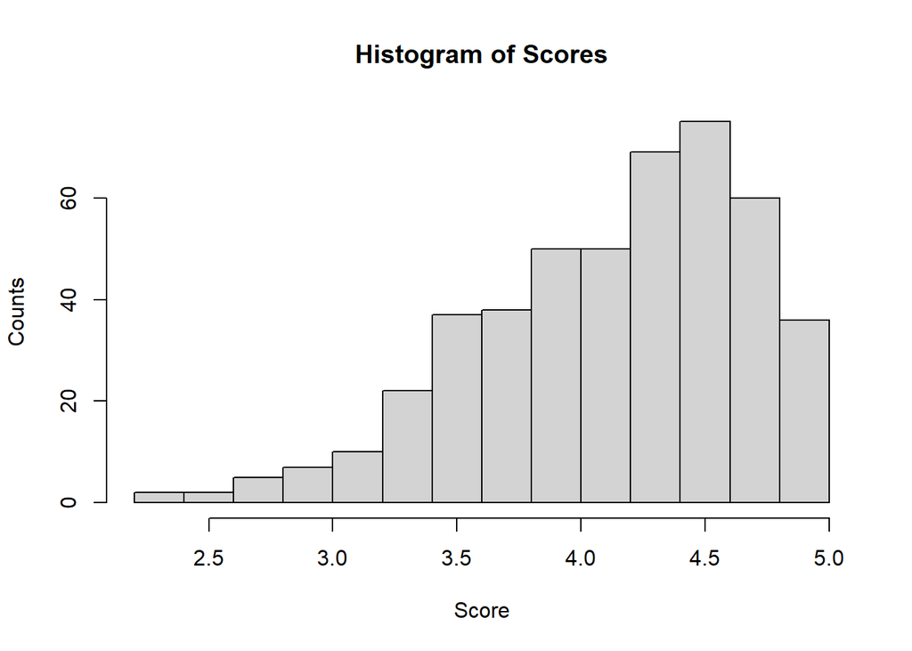

```r
hist(evals$score, xlab = "Score", ylab = "Counts", main = "Histogram of Scores")
```

The expectation was a normal distribution (unimodal, bell-shaped around the middle median/mean of 2.5) but this did not occur. The distribution is left skewed which means students rated more positively. This means that either the professors were all great and the random sample resulted in higher numbers of positive ratings by chance, or something else is going on here.

### Exercise 3

Excluding score, select two other variables and describe their relationship with each other using an appropriate visualization.

Two other variables are the average beauty score and ethnicity. Their distributions are displayed in the boxplots below with the language of the school where the professor received education as a third variable for reference.

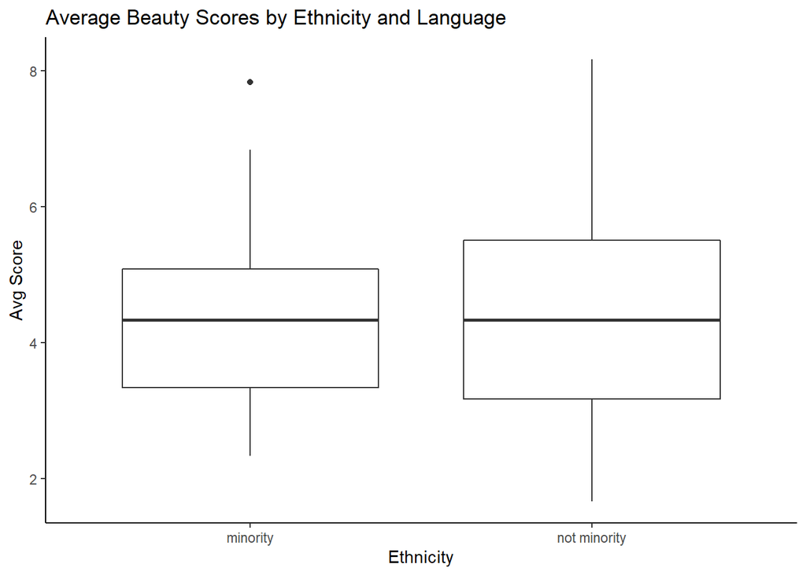

```r
ggplot(evals, aes(bty_avg, ethnicity)) + geom_boxplot() + coord_flip() + theme_classic() + labs(x = "Avg Score", y = "Ethnicity", title = "Average Beauty Scores by Ethnicity and Language")
```

We can see the relationship between ethnicity and the average beauty score is about the same between minorities and non-minorities. Their interquartile range is also comparable but minority ethnicities are slightly tighter in distribution than non-minorities. The outer range of nonminorities is wider than minorities. I wonder if this would change if we included new boxplots for professors who went to english and non-english schools.

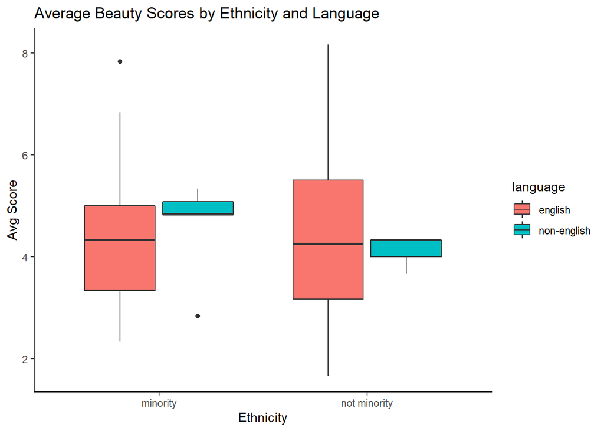

```r
ggplot(evals, aes(bty_avg, ethnicity, fill = language)) + geom_boxplot() + coord_flip() + theme_classic() + labs(x = "Avg Score", y = "Ethnicity", title = "Average Beauty Scores by Ethnicity and Language")
```

There is certainly a difference in distribution between the ethnicities who’s education was received in english and those who received an education that was not in english. For example, minorities that had a non-english education had higher beauty scores on average than those whose education was in english. However, the results are different for non-minorities. This group had an average very close to the average score for all non-minorities that received an education in english.